# sandbox-01

Joshua Rosenberg

12/27/2017

# Sandbox - 03

### Background

This is a sandbox for exploring the data, in preparation for adding to the results section.

This document is organized around two sets of model specifications:

1. Fit using the R package `mclust`
2. Fit using the commerical software `MPlus`

Both are interfaced to through the `tidyLPA` package.

### Models that are specified

**mclust**

For models fit using `mclust`, eight model specifications are tested, where all five refers to the variables for cognitive (learning), behavioral (hard working), and affective (enjoy), and challenge and competence, where three refers to just the three engagement measures. Note that the prior is to regularize the parameter estimates to be more less likely to be extreme (and therefore to be less likely to lead to convergence problems, but possibly less meaningful / interpretable).

- All five variables w/ no prior
- All five w/ prior
- All five w/ no prior and standardized (M = 0, SD = 1) variables
- All five w/ prior and standardized (M = 0, SD = 1) variables
- Three variables w/ no prior
- Three w/ prior
- Three w/ no prior and standardized (M = 0, SD = 1) variables
- Three w/ prior and standardized (M = 0, SD = 1) variables

*MPlus*

# 1. Processing data

# 1. mclust profiles

### 1A. All five - no prior

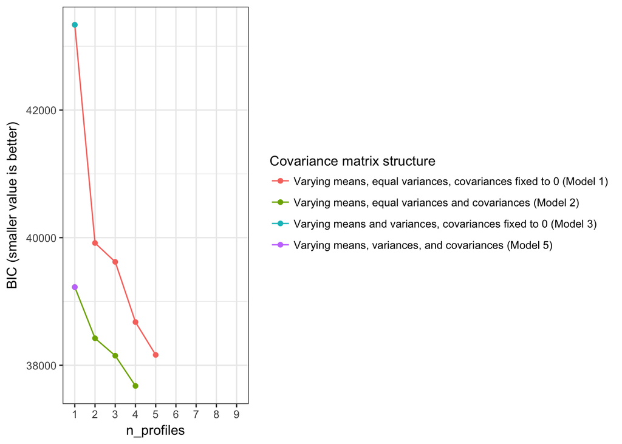

### 1B. All five - prior

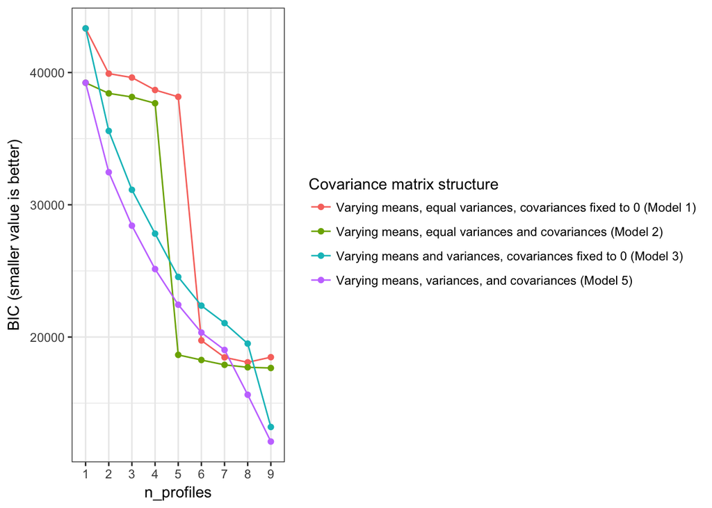

### 1C. All five - no prior - standardized

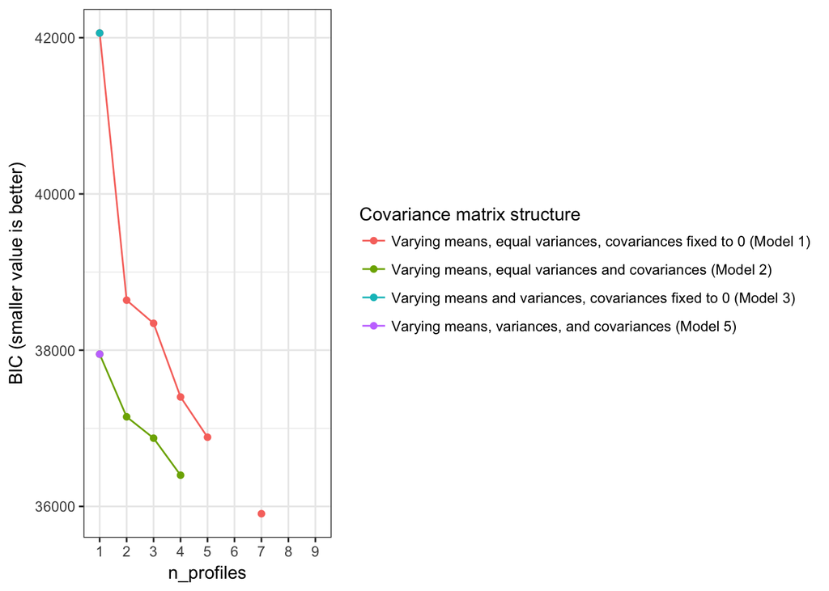

### 1D. All five - prior - standardized

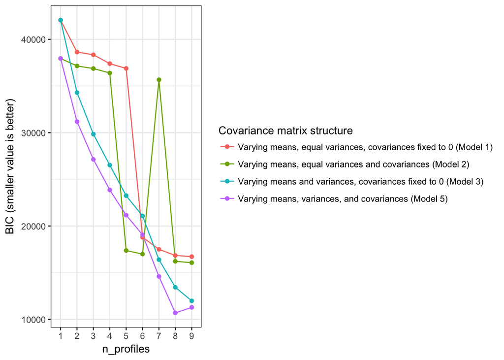

### 1E. Three - no prior

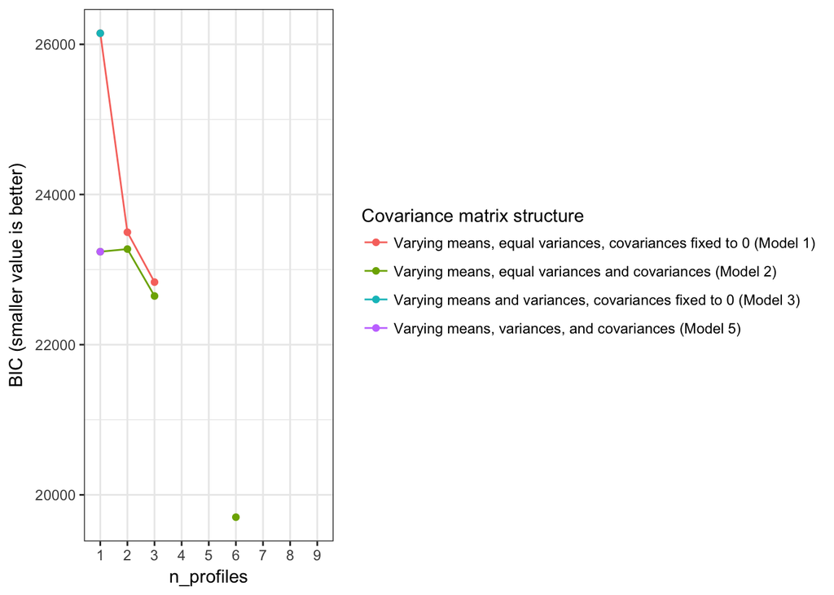

### 1F. Three - prior

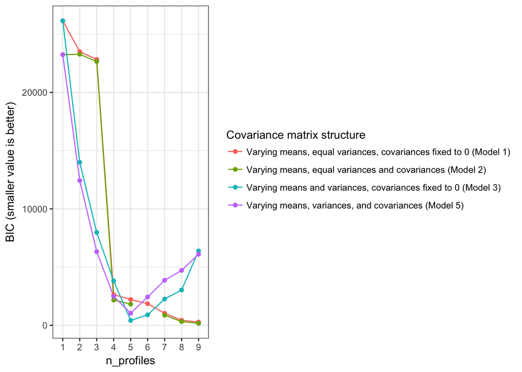

### 1G. Three - no prior - standardized

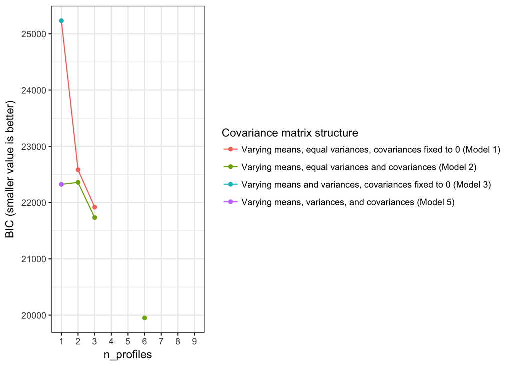

### 1H. Three - prior - standardized

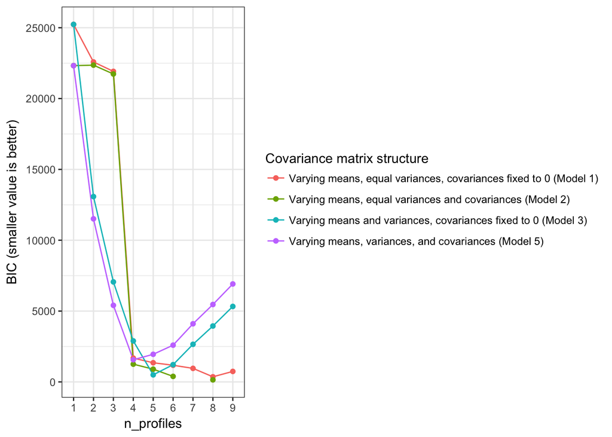

# Mplus

### 2A: All five variables w/ no prior

```
## TITLE: Your title goes here
## DATA: FILE = "d.dat";
## VARIABLE:
## NAMES = dm_cog_eng dm_beh_eng dm_aff_eng dm_challenge dm_competence;
## MISSING=.;
```

[output not shown]

[output cut: 365 more lines]

```
## 5          6           37711.149         37076.455 Convergence problem
## 6          7           37182.108         36874.378 Convergence problem
## 7          8           37268.057 LL not replicated Convergence problem
## 8          9 Convergence problem         36432.012 Convergence problem
## 9         10           36629.682         36328.909 Convergence problem
##               model_4             model_5
## 1 Convergence problem Convergence problem
## 2 Convergence problem Convergence problem
## 3 Convergence problem Convergence problem
## 4 Convergence problem Convergence problem
## 5 Convergence problem Convergence problem
## 6 Convergence problem Convergence problem
## 7 Convergence problem Convergence problem
## 8 Convergence problem Convergence problem
## 9 Convergence problem Convergence problem
```

### 2B: All five w/ no prior and standardized (M = 0, SD = 1) variables

[output not shown]

[output cut: 370 more lines]

```
## 5          6           36434.745         35800.052 Convergence problem
## 6          7           35905.704         35597.975 Convergence problem
## 7          8           35991.654 LL not replicated Convergence problem
## 8          9 Convergence problem         35155.608 Convergence problem
## 9         10           35353.278         35052.505 Convergence problem
##               model_4             model_5
## 1 Convergence problem Convergence problem
## 2 Convergence problem Convergence problem
## 3 Convergence problem Convergence problem
## 4 Convergence problem Convergence problem
## 5 Convergence problem Convergence problem
## 6 Convergence problem Convergence problem
## 7 Convergence problem Convergence problem
## 8 Convergence problem Convergence problem
## 9 Convergence problem Convergence problem
```

### 2C: Three variables w/ no prior

[output not shown]

[output cut: 370 more lines]

```
## 5          6           21696.726 LL not replicated Convergence problem
## 6          7 Convergence problem         21089.947 Convergence problem
## 7          8           21197.108 LL not replicated Convergence problem
## 8          9            20857.06 LL not replicated Convergence problem
## 9         10 Convergence problem         20444.102 Convergence problem
##               model_4             model_5
## 1 Convergence problem Convergence problem
## 2 Convergence problem Convergence problem
## 3 Convergence problem Convergence problem
## 4 Convergence problem Convergence problem
## 5 Convergence problem Convergence problem
## 6 Convergence problem Convergence problem
## 7 Convergence problem Convergence problem
## 8 Convergence problem Convergence problem
## 9 Convergence problem Convergence problem
```

### 2D: Three w/ no prior and standardized (M = 0, SD = 1) variables

[output not shown]

[output cut: 370 more lines]

```
## 5          6           20782.237 LL not replicated Convergence problem
## 6          7 Convergence problem         20175.458 Convergence problem
## 7          8           20282.619 LL not replicated Convergence problem
## 8          9           19942.571 LL not replicated Convergence problem
## 9         10 Convergence problem          19509.06 Convergence problem
##               model_4             model_5
## 1 Convergence problem Convergence problem
## 2 Convergence problem Convergence problem
## 3 Convergence problem Convergence problem
## 4 Convergence problem Convergence problem
## 5 Convergence problem Convergence problem
## 6 Convergence problem Convergence problem
## 7 Convergence problem Convergence problem
## 8 Convergence problem Convergence problem
## 9 Convergence problem Convergence problem
```